# S8_P2 Informe

### **Estadística y Probabilidades I**

#### *Hábitos de los estudiantes de UTEC y su impacto*

## 1. Introducción:

## 1.1 Relevancia:

- El estilo de vida es un determinante importante para la salud, la cual integra hábitos y conductas que muestra la vida diaria de las personas, especialmente en los universitarios, ya que en ellos se desarrollan y se consolidan los estilos de vida (saludables o perjudiciales).Por ende, es importante informar a la población a través del proyecto de investigación que se realizó, la cual esta basado en un estudio realizado a los estudiantes de la Universidad de Ingeniería y Tecnología(UTEC) sobre los hábitos saludables y/o no saludables que son parte de la rutina que llevan durante su vida universitaria. En conclusión, nos permitirá conocer el impacto que existe en el desempeño académico, la salud física, emocional o mental en los estudiantes de UTEC.

## 1.2 Factibilidad:

- Es factible debido a que tenemos fácil acceso a la población de estudio y podemos obtener los datos al realizar encuestas a una muestra determinada de estudiantes, a partir de ello, se realizará un estudio óptimo que nos permitirá llegar a una conclusión pertinente.
1. *¿Es el estudio de interés para la audiencia?*
   - Sí, debido a que podrán conocer acerca de los hábitos de los demás estudiantes y de esa manera poder establecer relaciones en base a ello. Además, esta temática tiene importancia en el ámbito universitario ya que puede influir directamente en el aprendizaje de los estdiantes de UTEC.
2. *¿Qué información se desea aportar al final del estudio?*
   - Se desea aportar información acerca de cuales son los hábitos comunes de los estudiantes, si existe una relación entre los hábitos y su salud, rendimiento académico, y de esta manera saber si se deberían realizar intervenciones para una mejora en los hábitos.
3. *¿Es posible llegar a la información que se propone de manera específica y concreta?*
   - Sí, ya que nuestra población objetivo serían los estudiantes de nuestra misma universidad, por lo tanto, tenemos cercanía con ella, además la estructuración de la encuesta ayudará a obtener los datos necesarios de manera efectiva.

## 2. Datos:

## 2.1 Recolección de datos:

### Los datos se obtuvieron de la siguiente manera:

- 1. Obtener información de Counter Alumnos, sobre la cantidad total de estudiantes de acuerdo a sus carreras en UTEC.
- 2. Determinar que se realizará la encuesta al 10% de estudiantes de cada carrera.
- 3. Establecer 371 observaciones como mínimo.Ya que equivale al 10% del total.

[output not shown]

**¿Por qué se hizo de esta manera?**

- Se realizó de esta manera, porque nuestro objetivo fue hacer una encuesta en una muestra representativa, donde se puedan obtener muestras proporcionales de cada carrera.

**Estrategias para llegar a la población:**

- 1. Para la recolección de datos, nuestra encuesta fue enviada a diferentes grupos de las redes sociales. Además de ser enviadas por correo electrónico.
- 2. Contactar con estudiantes que pertenecen a carreras con pocos alumnos, ya que ellos ayudarán a compartir la encuentra con sus compañeros de dichas carreras o ciclos superiores.
- 3. Agregar el link de la encuesta en un Excel, brindada por la directiva SWEeties & He4SWE, la cual permitía que otros estudiantes puedan acceder a nuestra encuesta.
- 4. Evitar compartir la encuesta en los grupos de alumnos del segundo ciclo y de la carrera de ingeniería industrial, ya que fueron los primeros en alcanzar dicho porcentaje propuesto en el grupo.
- 5. Acudimos de manera presencial a la Universidad para completar el porcentaje propuesto.

## 2.2 Población, muestra y muestreo:

- **Población de estudio:** Los estudiantes de UTEC.
- **Unidad muestral:** Un estudiante de UTEC.
- **Tamaño de la muestra:** 371 observaciones, esta representa el 10% de la población de estudio.
- **Tipo de muestreo:** El tipo de muestreo que se realizó es una combinación de el muestreo por conveniencia, muestreo aleatorio simple y muestreo estratificado.
  - *Muestreo por conveniencia:* En un principio la encuesta realizada fue enviada por las redes sociales (grupos de WhatsApp, Telegram) sin preocuparse de la procedencia de las respuestas.
  - *Muestreo aleatorio simple:* Al obtener las respuestas, seleccionamos una cantidad determinada de muestras por carrera (10%). Donde, todas las respuestas tenían las mismas probabilidades de ser elegidas.
  - *Muestreo estratificado:* Al lanzar la encuesta tomamos en cuenta la cantidad de estudiantes que seleccionaremos, el cual representa el 10% por carrera.

## 2.3 Variables:

- **Carrera:** Es una variable categórica nominal y la restricción es que solo se podía elegir una opción de las 12 opciones. Esta variable nos permitirá clasificar a los estudiantes por carrera. Asimismo, podremos obtener la carrera con mayor estudiantes que tiene hábitos saludables y la que tiene mayor estudiantes con hábitos no saludables.
- **Ciclo:** Es una variable categórica ordinal y la restricción es que solo se podía escoger un ciclo de los 10. Esta variable tiene la finalidad de obtener información acerca del ciclo en la que se encuentran los estudiantes.
- **Promedio Universidad:** Es una variable numérica continua y sus restricciones es que solo se podía digitar números de 0 a 20 (pueden ser decimales). Esta variables es fundamental ya que permite saber qué tanto puede influir los hábitos en el rendimiento académico en los estudiantes UTEC.
- **Edad:** Es una variable numérica discreta y sus restricciones es que solo se pudo elegir una opción del rango entre 15-50 años, utilizamos esta variable para conocer la edad de los estudiantes encuestados.
- **Estatura:** Es una variable numérica continua y sus restricciones es que solo permitia digitar números de 1 a 2.2 metros, con el fin de conocer la estatura de nuestros encuestados y partir de ello, obtener la relación que existe con los hábitos.
- **Peso:** Es una variable numérica continua y sus restricciones es que solo se podía digitar números de 30 a 120 kg, esta variable ayudará a determinar si existe una relación con los hábitos y el impacto en el rendimiento académico.
- **Sexo:** Variable categórica nominal, tiene como restricción que solo se podia elegir una opción de las 3 opciones (Masculino,Femenino,Prefiero no decirlo). La siguiente variable nos permite conocer el sexo de los estudiantes que participaron en la encuesta.
- **Sueño:** Es una variable numérica discreta y la restricción es que solo se podía elegir una opción de un número entero. Además, esta variable nos ayuda a saber la cantidad de horas que duermen nuestros encuestados, en la cual gracias a ello nos permitirá obtener la hora máxima y mínima, y otros descriptores numéricos que nos permitirá tener un mejor resultado de estudio, a su vez como esta puede afectar o no en los hábitos de los universitarios.
- **Alimentación:** Es una variable categórica nominal y la restricción es que solo se podía elegir un solo tipo de comida. Esta variable es fundamental ya que nos proporcionará información acerca del tipo de alimento que consumen los estudiantes de UTEC y como esta puede influir en su salud, bienestar y rendimiento académico.
- **Consumo de bebidas alcohólicas:** Es una variable categórica nominal y la restricción es que solo se podía escoger una opción de las dos opciones (si o no). Con esta variable se conocerá cuál de estas opciones predomina más y a su vez poder relacionarlo con otras variables para saber cómo influye en los hábitos y saber si esta puede repercutir en el desarrollo del universitario.
- **Consumo de agua:** Es una variable numérica discreta y sus restricciones es que solo se podía elegir una opción de cuantos litros de agua toman. Esta variable nos permitirá conocer la cantidad de agua en litros que consumen nuestros encuestados, como también saber cuál es la cantidad que predomina, el cual nos ayudará a tener un mejor análisis de cómo puede influir en su salud y en el rendimiento académico.
- **Tiempo de distracción:** Es una variable numérica continua y sus restricciones es que al momento de digitar la respuesta esta debería ser en el rango de 1 a 10 horas. Esta variable nos permitirá conocer el tiempo de distracción en horas que tienen los estudiantes de UTEC al día y su impacto en el rendimiento académico.
- **Nivel de estrés:** Es una variable categórica ordinal y la restricción es que solo se podía elegir una opción de las escala (nada estresado(a), poco estresado(a), estoy estresado(a), estoy muy estresado(a)). Esta variable nos permitirá conocer la moda con respecto al nivel de estrés que tienen los estudiantes de UTEC, el impacto en los hábitos y en el rendimiento académico.
- **Práctica de deporte:** Es una variable categórica nominal y la restricción es que solo se podía escoger una opción de las dos opciones. Esta variable nos permitirá conocer la cantidad de estudiantes que incluyen la practica de deportes en sus hábitos.
- **Deporte:** Variable categórica nominal, que tiene como restricción el que solo se pueda elegir una opción de los deportes que practican los estudiantes. Ello nos permitirá conocer qué deporte es el que más practican los estudiantes y si existe alguna relación entre la salud y el rendimiento académico.
- **Horas de deporte:** Variable categórica ordinal, donde la restricción es que solo pueden escoger un rango de tiempo en que realizan el deporte que seleccionaron antes. Permitirá saber cuánto es el tiempo máximo, mínimo y promedio que los estudiantes le dedican al deporte y encontrar posibles relaciones con otras variables que resuelvan incógnitas sobre los efectos en su vida diaria.
- **Promedio colegio:** Variable numérica continua, posee la restricción de que solo los estudiantes de primer ciclo podían visualizarla y que solo podían digitar números entre 0 y 20. La variable permite conocer el promedio de notas con la que ingresaron los estudiantes de primer ciclo a la universidad. A partir de ello, se relacionará con los hábitos que tienen..
- **Frecuencia del consumo de bebidas alcohólicas:** Es una variable categórica ordinal y sus restricciones es que solo se podía elegir una opción de la escala (muy poco (una vez en 2 meses), poco (una vez al mes), regularmente (dos veces al mes), bastante (una vez a la semana), muchísimo (tres veces a la semana)). Permitirá conocer si existe un alto o bajo consumo de bebidas alcohólicas entre los estudiantes universitarios y cómo esto afecta sus demás aspectos de vida.

## 2.4 Limpieza de datos:

- Eliminamos las primeras cinco variables (ID, Hora de inicio, Hora de finalización, Correo electrónico y Nombre). Debido a que no son relevantes para llegar a nuestro objetivo.

```r
DA <- DA[,(-1:-5),drop=FALSE]
```

- Renombramos las variables con el comando names(DA) para facilitar el uso de estas, en los siguientes procedimientos.

```r
names(DA)<-c("Carrera","Ciclo","P_Universidad","Edad","Estatura","Peso","Sexo","Sueño","Alimentacion","C_alcoholicas","C_agua","T_distraccion","N_estres","P_deporte","Deporte","H_deporte","P_Colegio","F_alcoholicas")
```

- A partir de las variables de Estatura y Peso creamos una nueva variable IMC, de la siguiente manera:

```r
var1 <- DA$Peso/(DA$Estatura)^2
```

```r
DA<-mutate(DA,IMC=var1)
```

```r
DA%>%group_by(Carrera="Ingeniería Industrial")%>%sample_n(60,replace = FALSE)->AA
DA%>%group_by(Carrera="Ingeniería Civil")%>%sample_n(47,replace = FALSE)->AB
DA%>%group_by(Carrera="Ingeniería Ambiental")%>%sample_n(21,replace = FALSE)->AC
DA%>%group_by(Carrera="Ingeniería Química")%>%sample_n(19,replace = FALSE)->AD
DA%>%group_by(Carrera="Ingeniería Electrónica")%>%sample_n(22,replace = FALSE)->AE
DA%>%group_by(Carrera="Ingeniería Mecatrónica")%>%sample_n(55,replace = FALSE)->AF
DA%>%group_by(Carrera="Ingeniería Mecánica")%>%sample_n(30,replace = FALSE)->AG
DA%>%group_by(Carrera="Ingeniería de la Energía")%>%sample_n(13,replace = FALSE)->AH
DA%>%group_by(Carrera="Bioingeniería")%>%sample_n(38,replace = FALSE)->AI
DA%>%group_by(Carrera="Administración y Negocios Digitales")%>%sample_n(9,replace = FALSE)->AJ
DA%>%group_by(Carrera="Ciencia de Datos")%>%sample_n(5,replace = FALSE)->AK
DA%>%group_by(Carrera="Ciencia de la Computación")%>%sample_n(52,replace = FALSE)->AL
```

- Se combinan las muestras de las 12 carreras en un solo date frame llamada “DA”.

```r
DA = rbind(AA,AB,AC,AD,AE,AF,AG,AH,AI,AJ,AK,AL)
```

## 2.5 Gráficos analizados:

- **Histograma de la variable Estatura:**

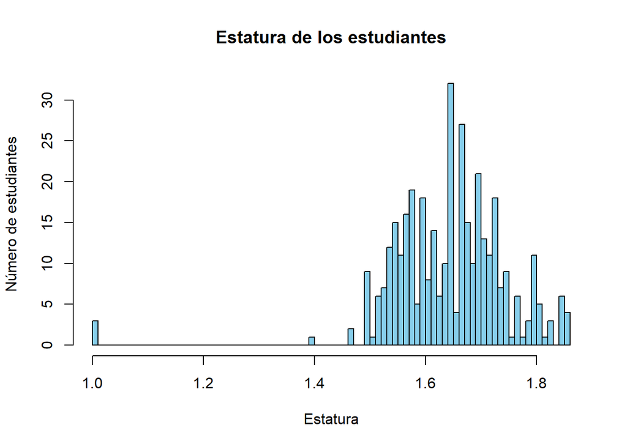

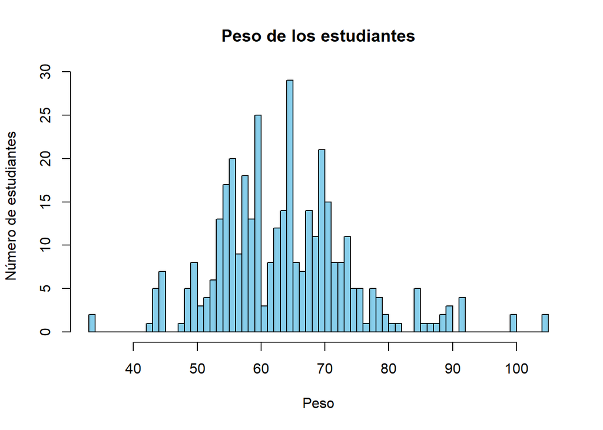

- Después de ver los resultados de las gráficas de peso y estatura, nos dimos cuenta que los datos obtenidos no parecen tan reales, ya que se observa que los estudiantes en mayor proporción, redondearon sus pesos y tallas en valores que terminan en 0 y 5, lo cual afecta la veracidad de nuestra data. Como nuestra base de datos ya está hecha, esta ya no se puede modificar, pero si fuera necesario obtener datos mas representativos, se tendría que acudir presencialmente para realizar las encuestas, contando con una cinta métrica y una balanza para poder tomar sus medidas de talla y peso, de esa manera estaremos seguros de tener una data con mayor confiabilidad.

# **3. Análisis descriptivo**:

## *3.1.Descriptores numéricos:*

1. Indice de masa corporal (IMC):
- Media, moda y mediana de la variable IMC:

```
## [1] 23.74
```

```
## [1] 24.17 24.22 22.43
```

```
## [1] 23.05
```

*Análisis:*

- Al obtener la moda, mediana y el promedio del indice de masa corporal se observa que los tres son cercanos a 24 y tienen una diferencia mínima. Por ello, se puede asumir que la población estudiantil esta dentro del rango (18.5 - 24.9) adecuado según el MINSA.
2. Promedio de la universidad (P_universidad):
- Media, mediana, moda, máximo y mínimo de la variable P_Universidad:

```
## [1] 15.53
```

```
## [1] 15.88
```

```
## [1] 16
```

```
## [1] 19.1
```

```
## [1] 0
```

```
## [1] 2.79
```

```
## [1] 10
```

```
## [1] 1
```

*Análisis:*

- Al realizar el promedio del tiempo de distraccion que tienen de los estudiantes de UTEC, se puede observar que en general se distraen tres horas al día, esto indica que la población estudiada da prioridad a otros asuntos (Estudio).
4. *Horas de sueño(Sueño):*
- Media, máximo y mínimo de la variable Sueño:

```
## [1] 6.24
```

```
## [1] 10
```

```
## [1] 1
```

*Análisis:*

## *3.2.Descriptores gráficos:*

## Analísis de las variables que indican hábitos en los estudiantes:

**1. Práctica de deportes - Nivel de estrés (nominal y ordinal)**

- Para que la gráfica se vea mas presentable se realizara la abreviación de las opciones que contiene la variable (N_estres).

```
##
##  Pearson's Chi-squared test
##
## data:  TD1
## X-squared = 26.844, df = 3, p-value = 6.346e-06
```

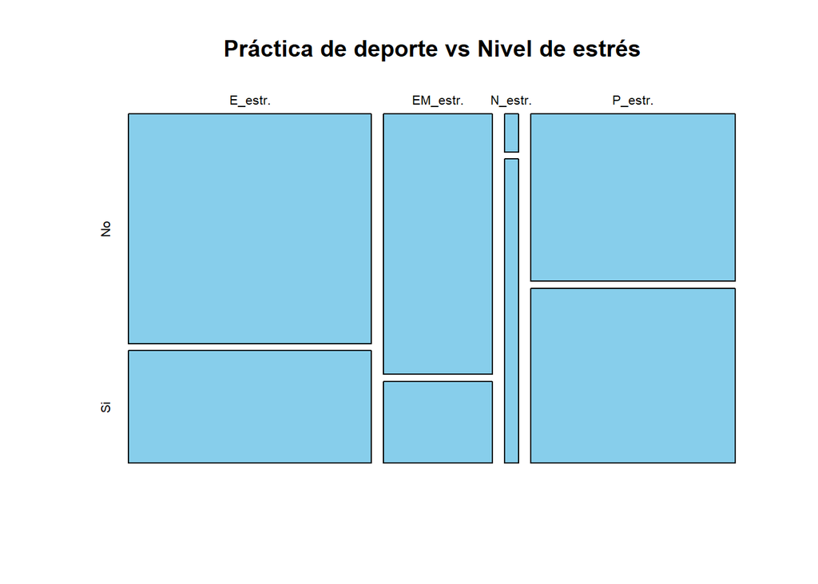

Donde:

- E_estr.= Estoy estresado(a)
- EM_str.= Estoy muy estresado(a)
- N_estr.= Nada estresado(a)
- P_str.= Poco estresado(a)

**Descripción:**

- Empleando esta gráfica de mosaico, de dos variables categóricas, se puede apreciar que aquellos que “sí” practican deporte se sienten “Poco estresado(a)”, la cual se da en mayor proporción. Por otra parte, aquellos universitarios que “no” realizan deporte se encuentran en el rango de “Estoy muy estresado(a)”, predominando más a comparación de las demás opciones.

**2. Práctica de deportes - Promedio de universidad (nominal y continua)**

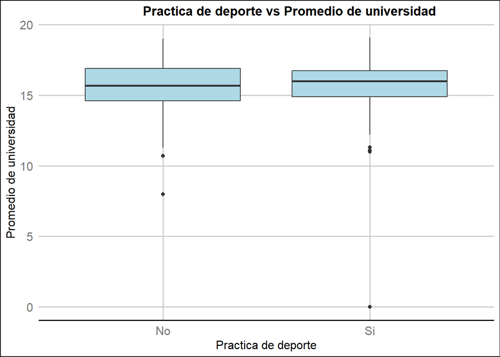

**Descripción:**

- Utilizando la gráfica del boxplot se puede conocer que al comparar ambas variables de “si” y “no” casi se asemejan en una tendencia minina en relación a su promedio, por lo cual para quienes practican deporte se tiene una mediana superior a los que no lo realizan (pasando de la nota 15).Por último, se puede concluir que la practica de deporte no afecta en el rendimiento académico de los universitarios(omitiendo los datos atípicos) según la gráfica analizada.

**3. Tiempo de distracción - Nivel de estrés (continua y ordinal)**

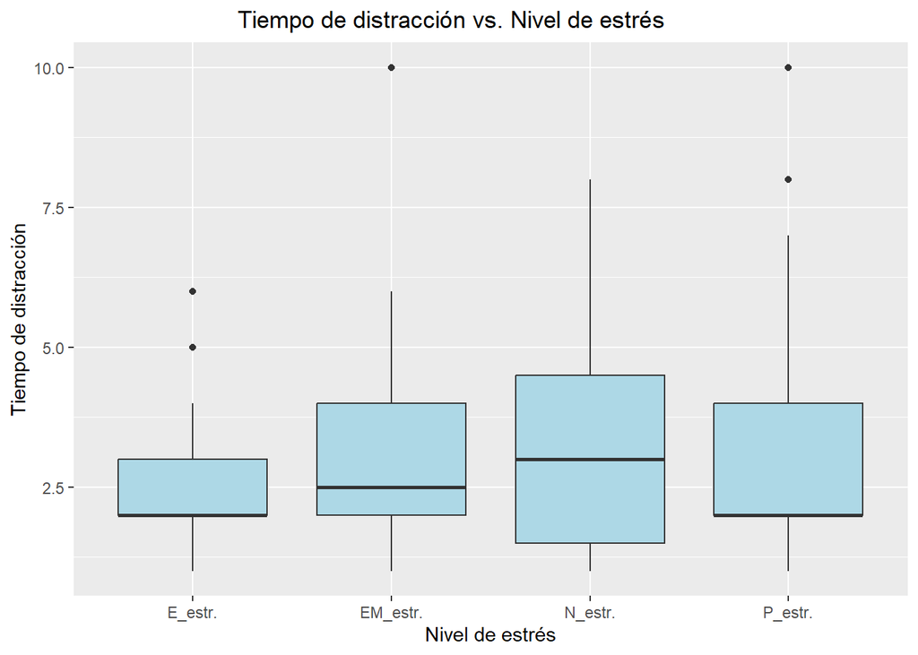

Donde:

- E_estr.= Estoy estresado(a)
- EM_str.= Estoy muy estresado(a)
- N_estr.= Nada estresado(a)
- P_str.= Poco estresado(a)

**Descripción:**

- Utilizando el gráfico boxplot para las variables de tiempo de distracción y nivel de estrés, se puede determinar que en nivel de estrés (poco estresado) presenta la mediana por otro lado los que están poco estresados usan menos tiempo de distracción y los datos son mas parecidos a diferencia de los nada estresados debido que hay mucha dispersión en sus datos, ademas que el tamaño es cantidad de horas,y que cada cajita tiene su mediana cuartil.

**4. Tiempo de distracción- Promedio de universidad (continua y continua)**

```
## [1] -0.119851
```

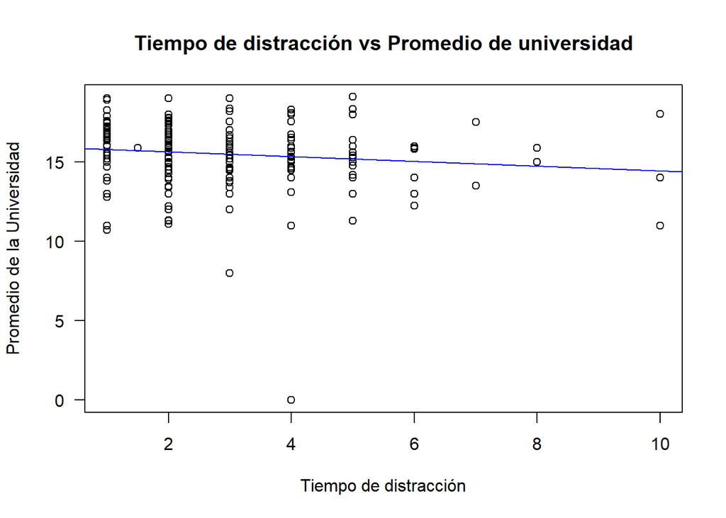

**Descripción:**

**5. Nivel de estrés - Promedio de universidad (ordinal y continua)**

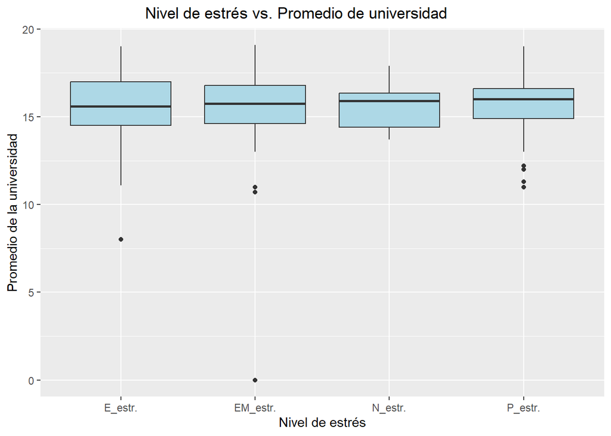

Donde:

- E_estr.= Estoy estresado(a)
- EM_str.= Estoy muy estresado(a)
- N_estr.= Nada estresado(a)
- P_str.= Poco estresado(a)

**Descripción:**

**6. Frecuencia del consumo de bebidas alcohólicas - Promedio de universidad (ordinal y continua)**

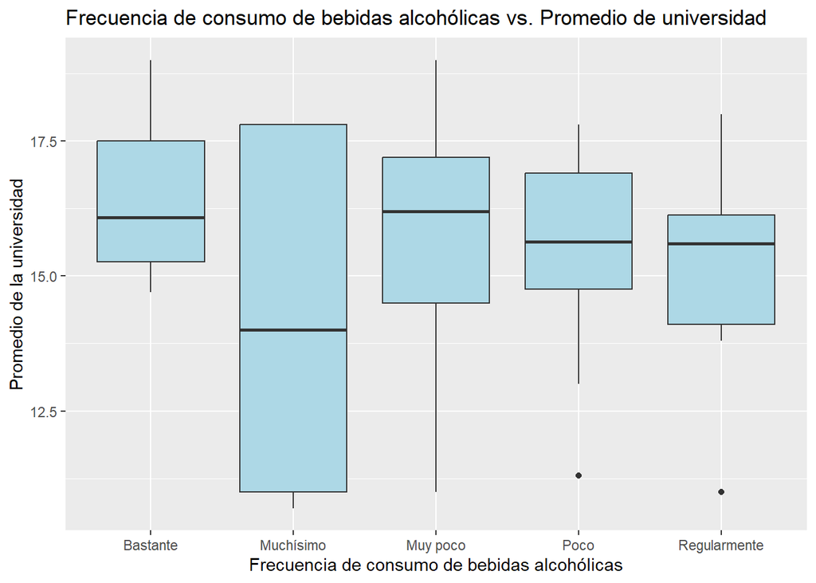

Donde:

- Muchísimo = Muchísimo (Tres veces a la semana)
- Bastante = Bastante (Una vez a la semana)
- Regularmente = Regularmente (Dos veces al mes)
- Poco = Poco(Una vez al mes)
- Muy poco = Muy poco( Una vez en 2 meses)

**Descripción:**

**7. Horas de sueño - Promedio de universidad (ordinal y continua)**

```
## [1] -0.002918058
```

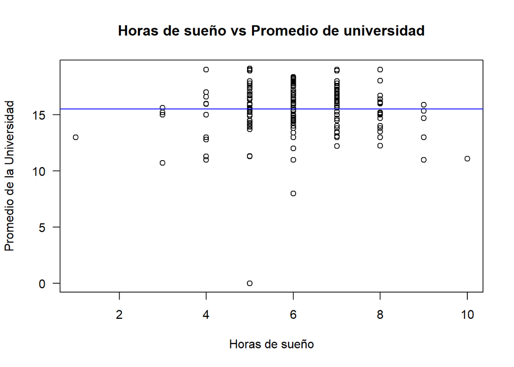

**Descripción:**

# **4. Análisis probabilístico**:

### **4.1 Variables aleatorias continuas:**

#### **4.1.1 P-universidad:**

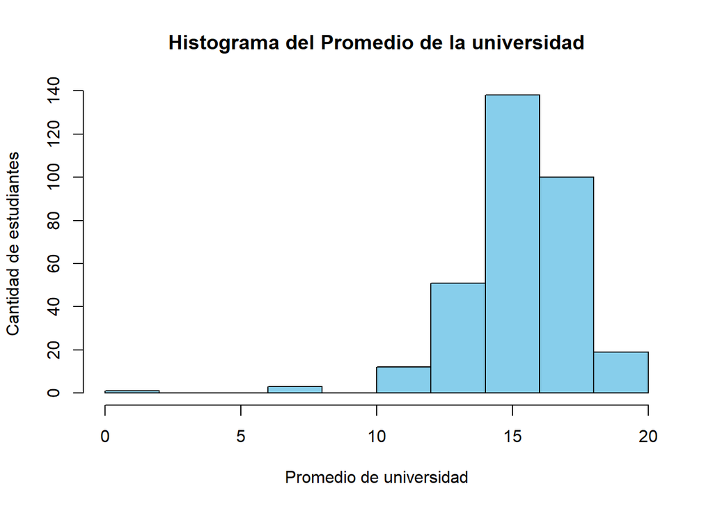

- Consideramos que la distribución de la variable de promedio universitario se puede distribuir de tipo normal por como se observa gráficamente.
- Sacaremos los datos atípicos para el mejor modelamiento de datos.

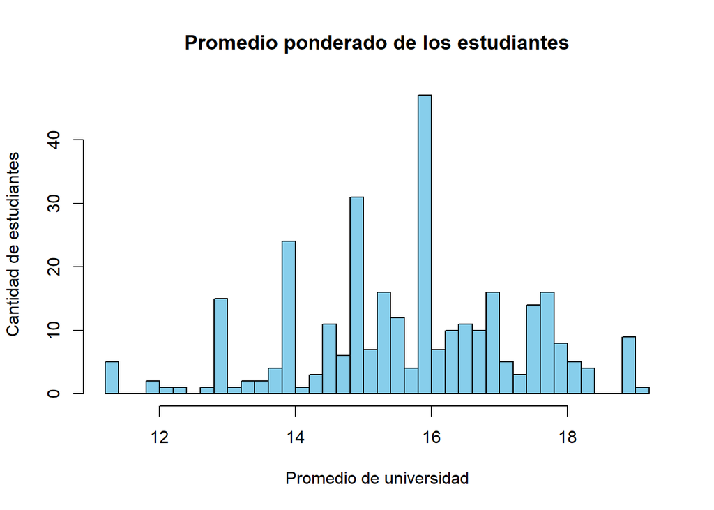

- Como podemos observar, claramente se ve la campana de la normal. Ahora usaremos la librería fitdist para poder estimar la distribución y sus parámetros

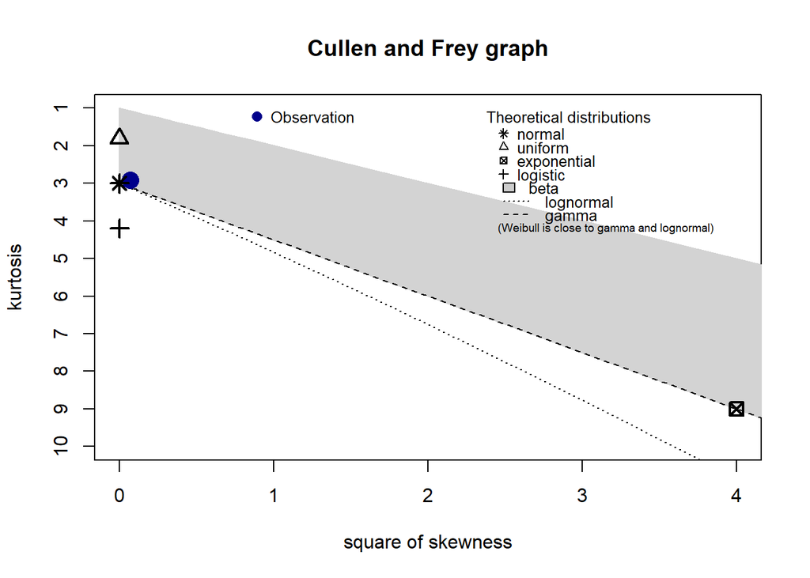

```
## summary statistics
## ------
## min:  11.29   max:  19.1
## median:  15.9
## mean:  15.72422
## estimated sd:  1.61551
## estimated skewness:  -0.2663089
## estimated kurtosis:  2.910293
```

- Ahora que la función descdist nos sugiere que la variable P_Universidad se puede modelar como una distribución normal estimaremos los parámetros. Esto tiene sentido teóricamente por que toda muestra de una muestra se distribuye normalmente.

```
## Fitting of the distribution ' norm ' by maximum likelihood
## Parameters:
##       estimate Std. Error
## mean 15.724222 0.09087910
## sd    1.612944 0.06426111
```

```r
prob1 <- pnorm(c(18,20),mean=15.4,sd = 1.8)
diff(prob1)
```

```
## [1] 0.06900608
```

#### **4.1.2 Tiempo de distracción:**

La variable tiempo de distracción es importante debido a que representa el rompimiento de un habito. La variable Tiempo de distracción nos dice la cantidad de veces que los alumnos se distraen a diario.

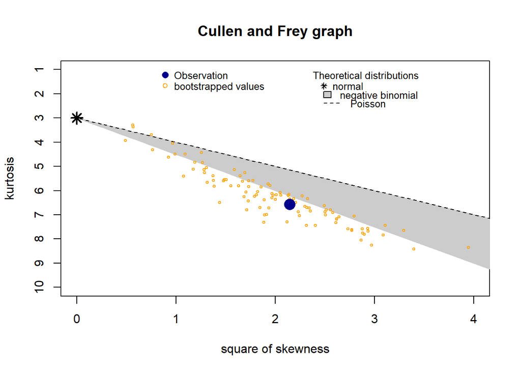

```
## summary statistics
## ------
## min:  1   max:  10
## median:  2
## mean:  2.789757
## estimated sd:  1.605397
## estimated skewness:  1.465144
## estimated kurtosis:  6.565801
```

```
## Fitting of the distribution ' pois ' by maximum likelihood
## Parameters:
##        estimate Std. Error
## lambda 2.789757  0.0867154
```

```r
ppois(3,(2.9),lower.tail = FALSE)
```

```
## [1] 0.3303766
```

#### **4.1.3 Estatura:**

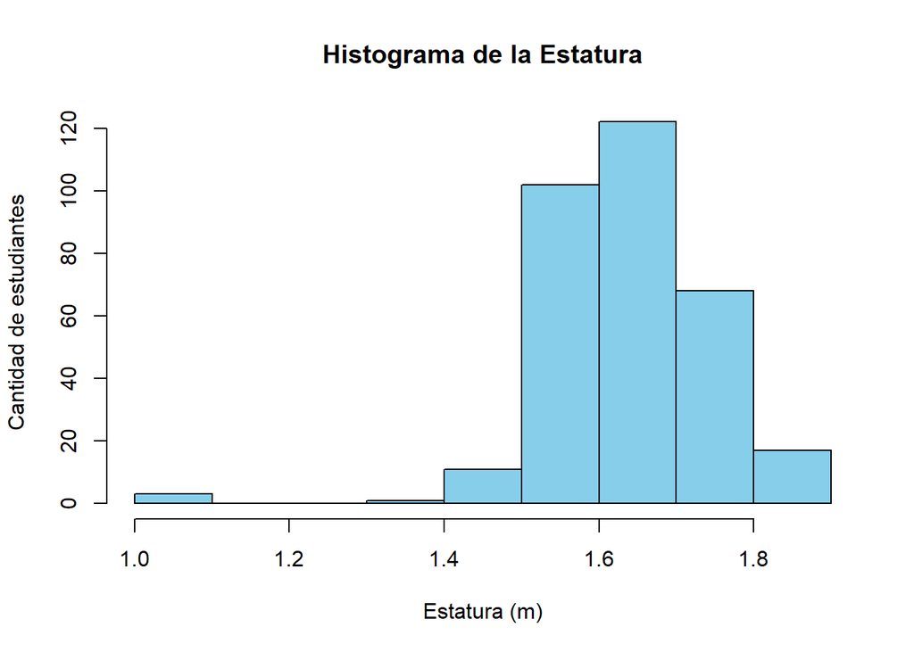

- Podemos observar que la distribución de los datos es muy similar a una normal. Y esto tendría sentido porque se trata de una variable continua que suele modelarse de dicha forma.

Calculamos su desviación estándar y su media:

```
## [1] "DESVIACIÓN ESTÁNDAR:"
```

```
## [1] 0.1085523
```

```
## [1] "MEDIA:"
```

```
## [1] 1.645
```

- Observamos que a comparación del promedio universitario, la variables des. estándar y media de la Estatura tienden a estar más normalizadas. Sin embargo, no lo están ya que su desviación estándar es de 0.11 y su media es de 1.65, cuando lo ideal debería ser 0 (media) y 1 (desviación estándar).

#### **4.1.4 Peso:**

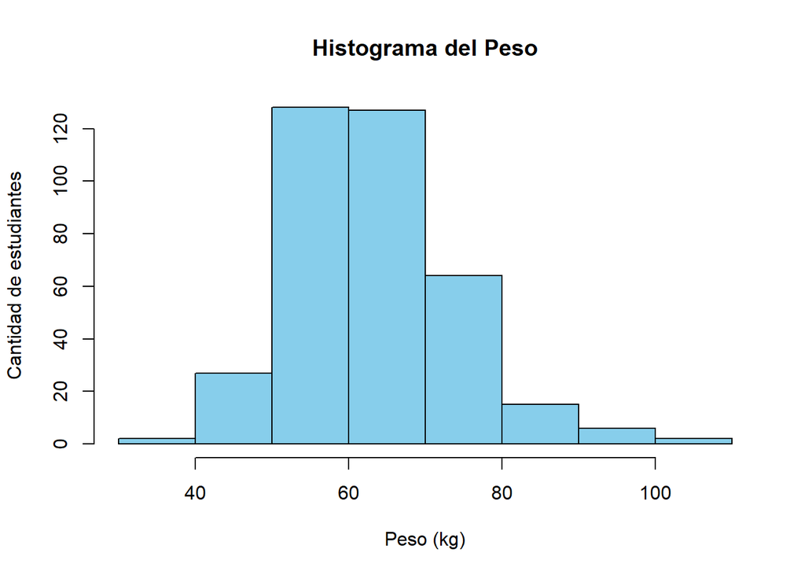

- Observando el histograma graficado podemos considerar el comportamiento de la variable peso como una variable aleatoria normal.

Calculamos su media y desviación estándar:

```
## [1] "DESVIACIÓN ESTÁNDAR:"
```

```
## [1] 10.91522
```

```
## [1] "MEDIA:"
```

```
## [1] 64.17346
```

## *4.2 Variables aleatorias discretas:*

#### **4.2.1 Edad:**

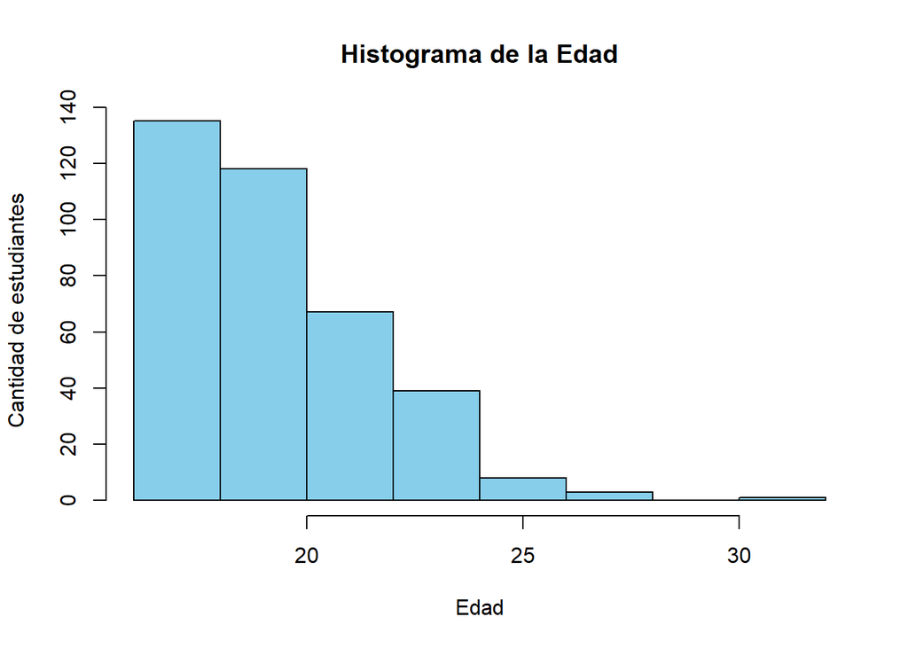

- Teóricamente podemos decir que la edad viene a ser una variable de carácter discreta. Ahora, al observar el gráfico se podría decir que se comporta como una binomial negativa, o distribución de Pascal. A continuación lo confirmaremos haciendo la prueba de Cullen and Frey.

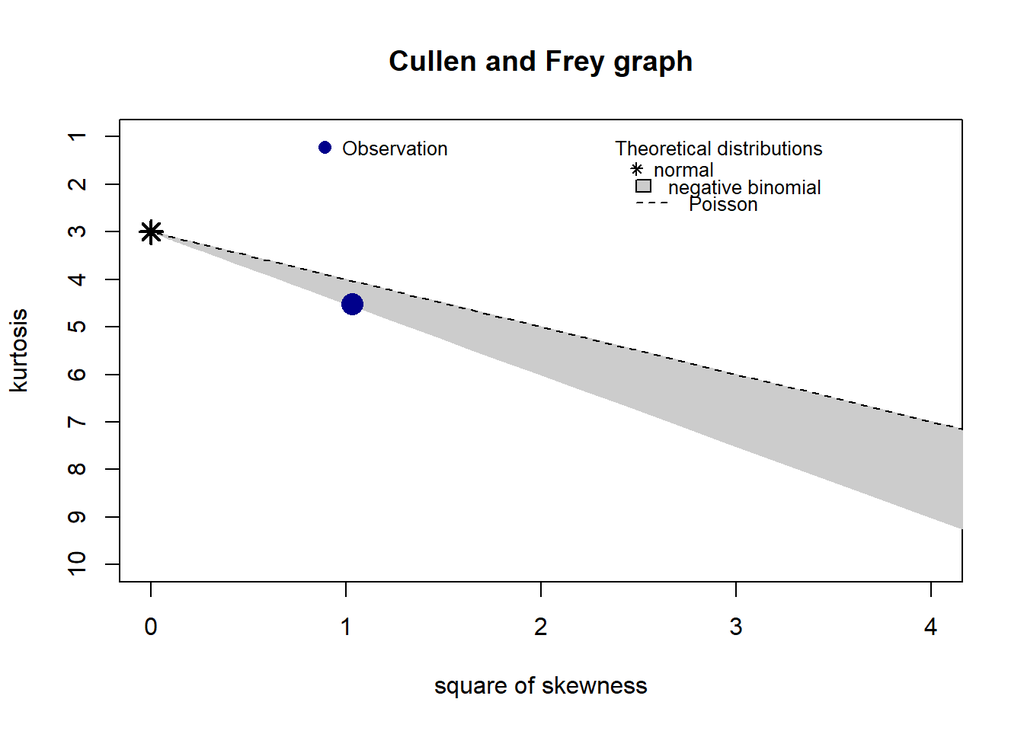

```
## summary statistics
## ------
## min:  16   max:  31
## median:  19
## mean:  19.72507
## estimated sd:  2.320273
## estimated skewness:  1.015598
## estimated kurtosis:  4.51863
```

- Podemos observar que efectivamente su comportamiento es más cercano a una binomial negativa. Por lo que concluimos que la variable Edad se comporta como una binomial negativa.

#### **4.2.2 Practica o no practica deporte:**

```
##
##  No  Si
## 226 145
```

```
## [1] "Probabililidad que SI practique deporte:"
```

```
## [1] 0.4043127
```

```
## [1] "Probabililidad que NO practique deporte:"
```

```
## [1] 0.5956873
```

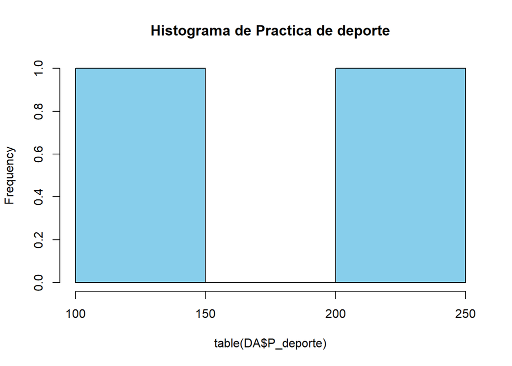

- Observamos que la variable de practica o no practica deporte sigue un comportamiento Bernoulli, ya que se podría considerar como practica a un “1” y como que no a un “0” al ser solo dos eventos (sí y no) en este caso la P (probabilidad que haga deporte) sería 0.4 y la 1-p 0.6.

#### **4.2.3 Consumo de bebidas alcohólicas:**

- Se repite lo mismo con el consumo de bebidas alcohólicas:

```
##
##  No  Si
## 237 134
```

```
## [1] "Probabililidad que consuma bebidas alcohólicas:"
```

```
## [1] 0.3881402
```

```
## [1] "Probabililidad que NO consuma bebidas alcohólicas:"
```

```
## [1] 0.6118598
```

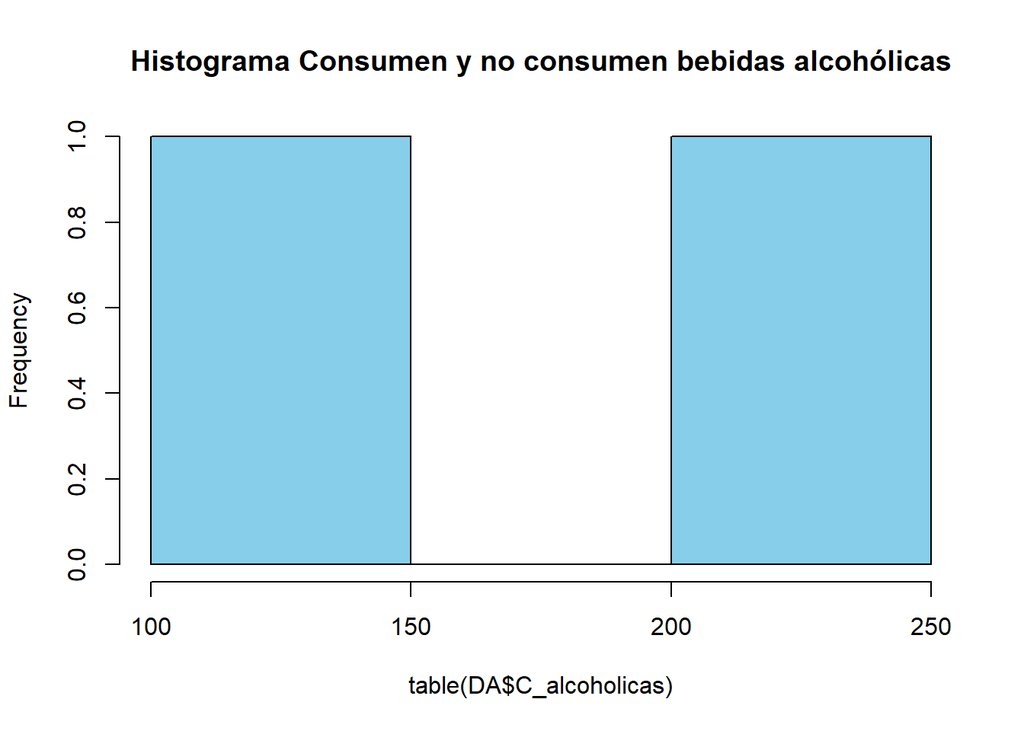

+ Podemos decir que el comportamiento de esta variable también es bernoulli ya que se cuenta con dos eventos. Probabilidad de que consuma bebidas alcohólicas (1) p=0.38 y la probabilidad que nuestro encuestado no consuma bebidas alcohólicas(0) 1-p = 0.611.

```r
dfIdeal <- filter(DA, IMC > 18.5 & IMC <24.9)
```

**Pregunta 1:**

- Si escojo a 20 estudiantes al azar , ¿Cuál es la probabilidad de que 10 de ellos este en su peso ideal?

```r
dbinom(10,20,PIMC)
```

[output not shown]

```
## [1] 0.01162645
```

**Pregunta 2:**

- Queremos saber si de 30 estudiantes. ¿Cuál es la probabilidad que 15 o menos estén en su peso ideal?

```r
pbinom(15,30,PIMC)
```

```
## [1] 0.003533352
```

**Pregunta 3:**

```r
pbinom(11,30,1-PIMC, lower.tail=TRUE)
```

```
## [1] 0.940358
```

# **5. Bibliografía**:

- Ramírez-Alán, O. (09 de octubre de 2017). Correlación y Regresión Lineal. RPubs. https://rpubs.com/osoramirez/316691
- Sánchez, A. (17 de enero de 2015). El 35,5% de la población peruana de 15 y más años de edad padece de sobrepeso.https://m.inei.gob.pe/prensa/noticias/el-355-de-la-poblacion-peruana-de-15-y-mas-anos-de-edad-padece-de-sobrepeso-9161/#:~:text=El%2035%2C5%25%20de%20la,e%20Inform%C3%A1tica%20%2D%20INEI%2C%20Dr
- Universia, C. (4 mayo de 2016). Los hábitos de sueño de los estudiantes universitarios.https://www.universia.net/cl/actualidad/vida-universitaria/habitos-sueno-estudiantes-universitarios-1139023.html
- Guijosa, C. (26 febrero de 2019). La distracción, un freno para la educación en línea.https://observatorio.tec.mx/edu-news/la-distraccion-un-freno-en-la-educacion-online
- Empresarial, Z. (26 septiembre de 2014). Impactante: estudiantes universitarios pasan 9 horas al día utilizando el celular.https://www.universia.net/co/actualidad/orientacion-academica/impactante-estudiantes-universitarios-pasan-9-horas-dia-utilizando-celular-1112139.html
- Empresarial, Z. (27 septiembre de 2020). El 85% de los peruanos prefieren consumir productos hechos a base de plantas y vegetales.https://zoomempresarial.pe/2020/09/27/el-85-de-los-peruanos-prefieren-consumir-productos-hechos-a-base-de-plantas-y-vegetales/